# 2026年05月07日 研究日志

今日主题：完成对已收集的4个数据集的样本归纳表。

| Dataset | Type | Total sample size | Sample source | Classification | Donor condition |
| --- | --- | --- | --- | --- | --- |
| **GSE29801** | Microarray | 293 | Retina, RPE-choroid | Organization type, region, donor's AMD condition | 31 normal, 26 AMD, 11 early‑stage AMD donors |
| **GSE91087** | Bulk RNA-seq | 6 | iPSC-RPE | donor AMD risk | 3 AMD, 3 normal donors |
| **GSE135092** | Bulk RNA-seq | 537 | Retina, RPE-choroid | Organization type, region, donor's AMD condition | 106 control, 23 AMD donors |
| **GSE135133** | snRNA-seq | 11 | Retina, RPE-choroid | cell type | 5 healthy donors |

*完成了……前段时间总结归纳的比较详细，没费多少时间就搞好了……尴尬，提前完工了。既然还有时间，讲讲我常用的R包`tidyverse`好了*

# `tidyverse` 是什么？

一句话总结：

> **tidyverse = 一组遵循相同设计的 R 包。是用来做数据导入、清洗、可视化和建模的一整套工具箱。**

它不是一个包，而是一个**生态系统**。  
当你 `library(tidyverse)` 时，默认加载的是：

- **dplyr**（数据操作）
- **tidyr**（数据整理）
- **ggplot2**（可视化）
- **readr**（读取数据）
- **purrr**（函数式编程）
- **tibble**（更现代的数据框）
- **stringr**（字符串处理）
- **forcats**（因子处理）

这些包的 API 风格一致、语法统一、返回值一致，还包含了方便编程的各种功能，符合我对代码的喜好。

```r
library(tidyverse)
```

# tidyverse 的核心：数据流

使用`tidyverse`之后：

- 操作变得可预测
- 可视化变得简单
- 自然而顺畅，符合人类直觉的管道操作（`|>` 或 `%>%`）
- 代码变得像“描述数据流变化”而不是“写命令”

↓ 这是一个利用tidyverse，对数据进行整理，使用三种组别的分组并绘制柱状图的代码

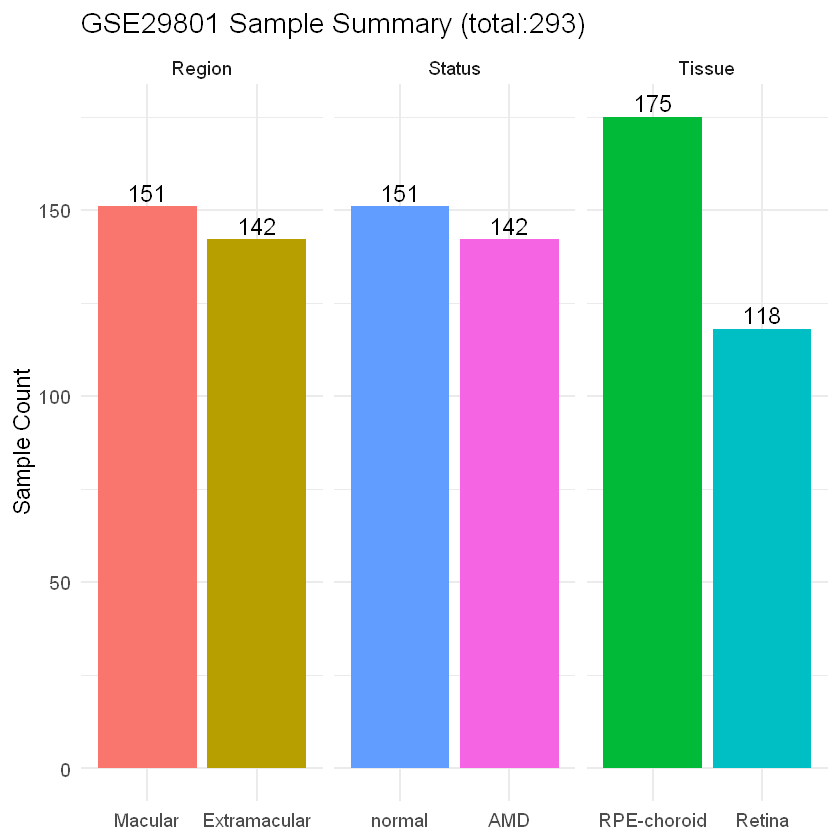

```r
# divided into 3 groups
df <- pheno |>
  as_tibble(rownames = "sample") |>
  separate(
    col = source_name_ch1,
    into = c("location_tissue", "status"),
    sep = ", ",
    remove = FALSE
  ) |>
  separate(
    col = location_tissue,
    into = c("region", "tissue"),
    sep = " ",
    extra = "merge"
  ) |>
  mutate(
    region = factor(region, levels = c("Macular", "Extramacular")),
    tissue = factor(tissue, levels = c("RPE-choroid", "Retina")),
    status = factor(status, levels = c("normal", "AMD"))
  )

# summary
df_long <- bind_rows(
  df |> dplyr::count(region)  |> mutate(dimension = "Region",  category = region),
  df |> dplyr::count(tissue)  |> mutate(dimension = "Tissue",  category = tissue),
  df |> dplyr::count(status)  |> mutate(dimension = "Status",  category = status)
) |>
  select(dimension, category, n)

# draw
df_long |>
  ggplot(aes(x = category, y = n, fill = category)) +
  geom_col() +
  geom_text(aes(label = n), vjust = -0.3, size = 5) +
  facet_wrap(~ dimension, scales = "free_x") +
  labs(
    title = "GSE29801 Sample Summary (total:293)",
    x = NULL,
    y = "Sample Count"
  ) +
  theme_minimal(base_size = 14) +
  theme(legend.position = "none")
```

这段代码就展现了 `tidyverse` 工作流的典型模式：**从原始表格 → 整洁数据 → 分组统计 → 可视化**。  
首先，使用 `separate()` 将 `source_name_ch1` 中混合的字符串拆分成更有意义的字段（区域、组织类型、疾病状态），并用 `mutate()` 将它们转换为有序因子，便于后续绘图。接着，通过 `count()` 分别统计三个维度的样本数量，并用 `bind_rows()` 将结果整理成长格式的整洁数据框。最后，利用 `ggplot2` 绘制分面柱状图，让不同维度的样本分布一目了然。

就这样，我们实现了这样的效果：**一步一步变换数据，每一步都清晰可读，最终自然衔接到可视化。**

*好了，今天的博客已经写好了……完成了预定明天完成的工作，明天干什么呢……算了，明天的事明天再说，各位，明天再见咯~*